# Week 2: Regression and model validation

*Describe the work you have done this week and summarize your learning.*

- Describe your work and results clearly.
- Assume the reader has an introductory course level understanding of writing and reading R code as well as statistical methods.
- Assume the reader has no previous knowledge of your data or the more advanced methods you are using.

```r
date()
```

```
## [1] "Fri Nov 12 17:46:37 2021"
```

## 1) Introduction to and exploration of the data

The data used for this exercise is derived from a study exploring the relationship between learning approaches and student’s achievements in an introductory statistics course in Finland conducted during years 2014 and 2015. Students in an introductory statistics course filled in a questionnaire exploring their learning approaches and study skills. The student’s achievements on the course were measured by the points they received in the exams. Only a part of the original data will be used in this exercise and is explored below. This smaller data set is in a data frame called *learning2014*.

```r
# import the data
learning2014 <- read.table("./Data/learning2014.txt", sep = "\t")

# structure of the data frame
str(learning2014)
```

```
## 'data.frame':    166 obs. of  7 variables:
##  $ gender  : chr  "F" "M" "F" "M" ...
##  $ age     : int  53 55 49 53 49 38 50 37 37 42 ...
##  $ attitude: num  3.7 3.1 2.5 3.5 3.7 3.8 3.5 2.9 3.8 2.1 ...
##  $ deep    : num  3.58 2.92 3.5 3.5 3.67 ...
##  $ stra    : num  3.38 2.75 3.62 3.12 3.62 ...
##  $ surf    : num  2.58 3.17 2.25 2.25 2.83 ...
##  $ points  : int  25 12 24 10 22 21 21 31 24 26 ...
```

```r
colSums(is.na(learning2014)) # number of missing values in the data
```

```
##   gender      age attitude     deep     stra     surf   points
##        0        0        0        0        0        0        0
```

There are 166 observations by 7 variables and no missing data in the data set.

Variables *age* and *gender* are self-explanatory, but the other 5 variables are explained below:

- **attitude**: student’s attitude towards statistics
- **surf**: surface approach for learning — memorizing without understanding (lack of purpose, unrelated memorizing)
- **deep**: deep approach for learning — intention to maximize understanding (relating ideas, use of evidence)
- **stra**: strategic approach for learning — maximizing the chance of achieving the highest possible grades (organized studying and time management)
- **points**: points received in the exams of the course (measure of student’s achievements)

Explanations for the variables are derived from [here](https://www.slideshare.net/kimmovehkalahti/the-relationship-between-learning-approaches-and-students-achievements-in-an-introductory-statistics-course-in-finland).

### Graphical overview of the data

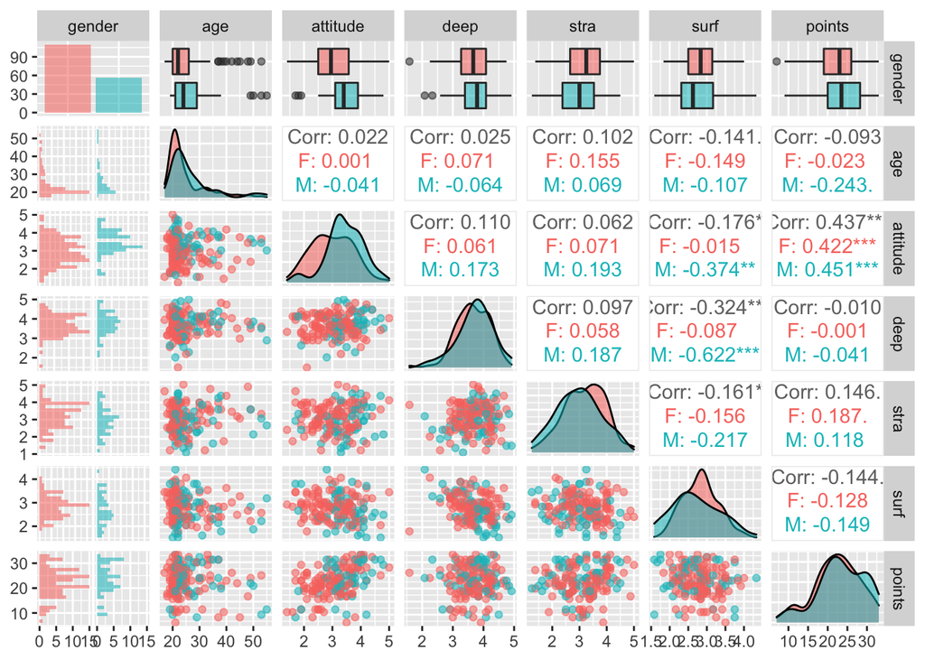

```r
# first upload the libraries
library(ggplot2)
library(GGally)
# now the graph
ggpairs(learning2014, mapping = aes(col = gender, alpha = 0.5),
        lower = list(combo = wrap("facethist", bins = 20)))
```

```r
# summaries of the variables in the data
summary(learning2014)
```

```
##     gender               age           attitude          deep
##  Length:166         Min.   :17.00   Min.   :1.400   Min.   :1.583
##  Class :character   1st Qu.:21.00   1st Qu.:2.600   1st Qu.:3.333
##  Mode  :character   Median :22.00   Median :3.200   Median :3.667
##                     Mean   :25.51   Mean   :3.143   Mean   :3.680
##                     3rd Qu.:27.00   3rd Qu.:3.700   3rd Qu.:4.083
##                     Max.   :55.00   Max.   :5.000   Max.   :4.917
##       stra            surf           points
##  Min.   :1.250   Min.   :1.583   Min.   : 7.00
##  1st Qu.:2.625   1st Qu.:2.417   1st Qu.:19.00
##  Median :3.188   Median :2.833   Median :23.00
##  Mean   :3.121   Mean   :2.787   Mean   :22.72
##  3rd Qu.:3.625   3rd Qu.:3.167   3rd Qu.:27.75
##  Max.   :5.000   Max.   :4.333   Max.   :33.00
```

The number of females is almost twice the number of males in the data, but there seems to be no significant difference between the females and males, except a slightly lower values in *attitude* seen in females compared to males (see the box plots on the top panel in the paired plot). However, this might be due to the lower number of male participants in the data. The *age* is between 17 – 55, but most of the participants fall below age 30. The rest of the variables (*attitude, deep, stra, surf, points*) seem to be close to normal distribution. Variables *points* and *attitude* correlate positively, while there is slight negative correlation between *deep* and *surf*. This negative correlation is only seen in the male participants.

## 2) Regression model

We will use regression analysis to see if we could build a model to predict *points* from the other variables. The dependent variable (response variable) here is *points* and we will choose three possible explanatory variables to start building the model. The three explanatory variables will be *attitude, stra* and *deep*.

```r
# We will start building the model using three explanatory variables
M1 <- lm(points ~ 1 + attitude + stra + deep, data = learning2014)
# Show a summary of the fitted model
summary(M1)
```

```
##
## Call:
## lm(formula = points ~ 1 + attitude + stra + deep, data = learning2014)
##
## Residuals:
##      Min       1Q   Median       3Q      Max
## -17.5239  -3.4276   0.5474   3.8220  11.5112
##
## Coefficients:
##             Estimate Std. Error t value Pr(>|t|)
## (Intercept)  11.3915     3.4077   3.343  0.00103 **
## attitude      3.5254     0.5683   6.203 4.44e-09 ***
## stra          0.9621     0.5367   1.793  0.07489 .
## deep         -0.7492     0.7507  -0.998  0.31974
## ---
## Signif. codes:  0 '***' 0.001 '**' 0.01 '*' 0.05 '.' 0.1 ' ' 1
##
## Residual standard error: 5.289 on 162 degrees of freedom
## Multiple R-squared:  0.2097, Adjusted R-squared:  0.195
## F-statistic: 14.33 on 3 and 162 DF,  p-value: 2.521e-08
```

According to the model summary, *attitude* shows a significant relationship with *points* in the model, meaning that *attitude* could be used to predict *points*. Together *attitude, stra* and *deep* explain 20.97% of *points* (this information is derived from the multiple R-squared).

Since *stra* and *deep* did not show significant relationship with *points* a new model is build by using the significant explanatory variable *attitude* only.

```r
M2 <- lm(points ~ 1 + attitude, data = learning2014)

summary(M2)
```

```
##
## Call:
## lm(formula = points ~ 1 + attitude, data = learning2014)
##
## Residuals:
##      Min       1Q   Median       3Q      Max
## -16.9763  -3.2119   0.4339   4.1534  10.6645
##
## Coefficients:
##             Estimate Std. Error t value Pr(>|t|)
## (Intercept)  11.6372     1.8303   6.358 1.95e-09 ***
## attitude      3.5255     0.5674   6.214 4.12e-09 ***
## ---
## Signif. codes:  0 '***' 0.001 '**' 0.01 '*' 0.05 '.' 0.1 ' ' 1
##
## Residual standard error: 5.32 on 164 degrees of freedom
## Multiple R-squared:  0.1906, Adjusted R-squared:  0.1856
## F-statistic: 38.61 on 1 and 164 DF,  p-value: 4.119e-09
```

Variable *attitude* explains 19.06% of *points* and this explanatory variable remains significant.

Next we can do model validation by drawing few diagnostic plots. Let’s focus on **residuals vs fitted values**, **normal QQ-plot** and **residuals vs leverage**.

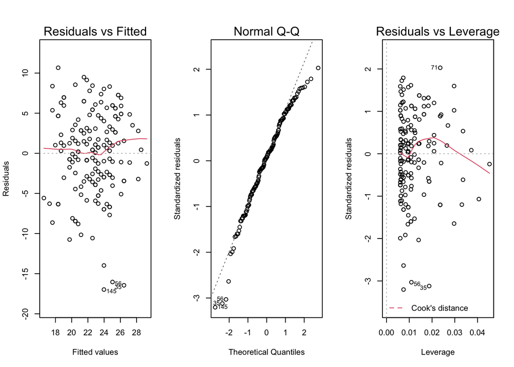

```r
par(mfrow=c(1,3)) # makes the plots appear in a 1x3 window
plot(M2, which = c(1,2,5)) # 1: residuals vs fitted # 2: normal QQ-plot # 5: residuals vs leverage
```

#### Plot: residuals vs fitted

According to this plot, the fitted regression model seems to be appropriate. The residuals are spread randomly in the plot, indicating that the errors do not depend on the explanatory variable.

#### Plot: normal Q-Q

The plot indicates that the errors of the model are normally distributed, since most of the residuals follow linearity.

#### Plot: residuals vs leverage

No single observation stands out in the plot, implicating that single observations do not have unreasonably high impact on the model.